# Denver Animal Protection - Violation Data & Prediction

Joseph Haymaker, The University of Pennsylvania

01/2018

[figure not shown]

# 1 Executive Summary

[figure not shown]

# 2 Description of the problem

### 2.0.1 Introduction

Denver Animal Protection is part of the City & County of Denver’s organizational structure and, as such, strives to serve all members of Denver County, an area comprised of 155 square miles ([US Census Data](https://www2.census.gov/geo/docs/maps-data/data/gazetteer/2017_Gazetteer/2017_gaz_counties_08.txt)) and 53 unique zip codes not associated with a specific company or organization ([source](https://tools.usps.com/go/ZipLookupAction!input.action), full list).More specifically, Denver Animal Protection (DAP) falls under the umbrella of Denver’s Department of Environmental Health (DEH), which oversees programs related to public health and environment. Within DEH there are seven different divisions (one of which is DAP): Community Health (CH), Public Health Inspection (PHI), Denver Animal Protection (DAP), the Office of Medical Examiner (OME), Environmental Quality (EQ), the Executive Director’s Office (EDO), and the Office of Sustainability (OOS) ([source](https://www.denvergov.org/content/dam/denvergov/Portals/344/documents/Budget/MayorsProposedBudget_2016.pdf)). While DAP garners much public attention, media attention generally focuses on its public facing roles of animal returns to owners and animal adoption ([1](https://www.denverpost.com/2017/11/01/denver-animal-shelter-adoption-deal/), [2](http://kdvr.com/2017/08/22/denver-animal-shelter-to-put-2-dozen-french-bulldogs-up-for-adoption-saturday/), [3](https://www.denverpost.com/2017/12/28/border-collie-deformed-front-legs-gets-cart/), [4](http://kdvr.com/2017/07/14/cat-found-in-west-denver-dumpster-finds-new-home/)). However, the shelter also offers a foster program, volunteer opportunities, a weekly vaccination clinic, pet licensing, breed evaluations, wildlife & pest control, and ordinance enforcement. Some of these services are offered at the shelter, while many others are performed by animal control officers who spend much of their time in the field. For example, in addition to enforcing Denver’s leash, pet waste, pet licensing, rabies vaccination, and spay/neuter laws, the field services unit also investigates animal bites, cruelty and neglect claims, and barking dog disturbances. One of DAP’s specific strategies is to “improve public safety and animal welfare by increasing compliance with Denver’s animal codes and improving pet responsibility through proactive outreach efforts” ([Mayor’s Proposed 2017 Budget](https://www.denvergov.org/content/dam/denvergov/Portals/344/documents/Budget/2017/2017%20Budget%20Book_October%20Draft_Web%20Version.pdf), p. 603). Consequently, with more perfect knowledge of city violation trends and predictors the field services unit will be better able to target public outreach opportunities with current resources, and in turn move in the direction of greater ordinance compliance in the county.

# 3 Description of the data

### 3.0.1 Data Summary

Citation data was kindly provided by the City & County of Denver ([5](https://www.denvergov.org/content/denvergov/en/denver-animal-shelter/about-das/contact.html), [6](https://www.denvergov.org/content/denvergov/en/denver-city-council/about-us/open-records-policy.html)) and consists of 32,018 entries of violations issued for a 5 year period from 2012-2017. There are 5 variables represented: `zip_code` (zip code of owner cited), `violation_type` (administrative or regular citation), `offense` (official ordinance number), `item_name` (description of violation), `animal_id` (unique animal identifier). Please see the appendix for more detailed information on ordinance numbers and descriptions.

It’s also worth mentioning that `animal_id` data, though not relevant here, shows that one animal was cited 16 times.

#### 3.0.1.1 Total citations by zip code

##### 3.0.1.1.1 Most cited zip codes

Given the fact that this investigation will focus on geographic considerations, I choose to examine the zip code data first. Several points are worth mentioning with respect to the zip code representation shown in this data. First is the the highest and lowest offending zip codes.

80012 80014 80123 80202 80203 80204 80205 80206 80207 80209 80210 80211 80212 80214 80216 80218 80219 80220 80221 80222 80223 80224 80226 80227 80230 80231 80232 80235 80236 80237 80238 80239 80246 80247 80249 80264 80290 80293 80294

Zip code discrepancies between the three sources were:

80022 80033 80110 80111 80127 80215 80225 80228 80229 80233 80234 80241 80256 80259 80260 80261 80262 80265 80266 80266 80273 80274 80280 80281 80291 80292 80295 80299

Using sources to triangulate true Denver county zip codes ([7](https://www.unitedstateszipcodes.org/), [8](https://www.denvergov.org/media/gis/WebDocs/Citywide/Neighborhoods.pdf)), I included (or failed to deem unnecessary) the following zip codes from the questionable list: 80110, 80265, 80266, 80292, and 80295. See the appendix for the final master list of zip codes used.

Using this information, the top ten zip codes based on citation frequency are:

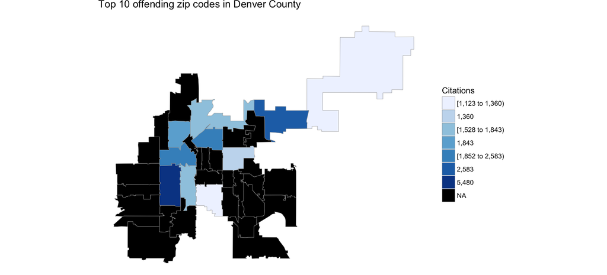

| Zip code | Number of citations |
| --- | --- |
| 80219 | 5480 |
| 80239 | 2583 |
| 80204 | 2093 |
| 80205 | 1852 |
| 80211 | 1843 |
| 80216 | 1581 |
| 80223 | 1528 |
| 80220 | 1360 |
| 80210 | 1336 |
| 80249 | 1123 |

As we can see in the map, the areas of most concern and subsequent proposed outreach are in the western-center part of the county (80219 in particular), and areas near DIA & bordering Adams County (Stapleton, Montbello, & Green Valley Ranch).

##### 3.0.1.1.2 Least cited zip codes

The lowest offending zip codes are:

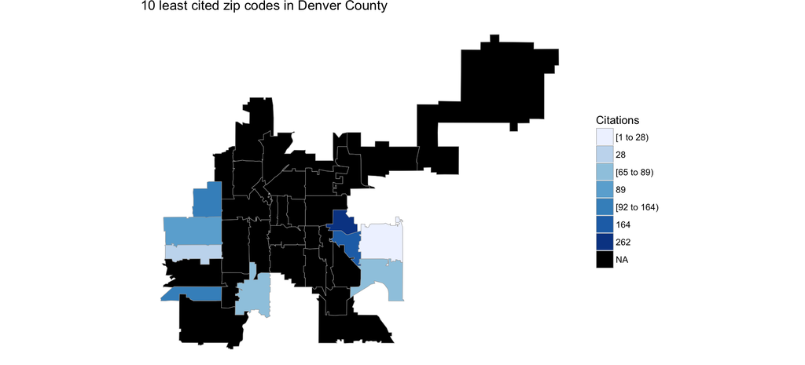

|  | Zip code | Number of citations |
| --- | --- | --- |
| 28 | 80230 | 262 |
| 29 | 80247 | 164 |
| 30 | 80214 | 102 |
| 31 | 80235 | 92 |
| 32 | 80226 | 89 |
| 33 | 80110 | 75 |
| 34 | 80014 | 65 |
| 35 | 80232 | 28 |
| 36 | 80012 | 20 |
| 37 | 80294 | 1 |

##### 3.0.1.1.3 All zip codes

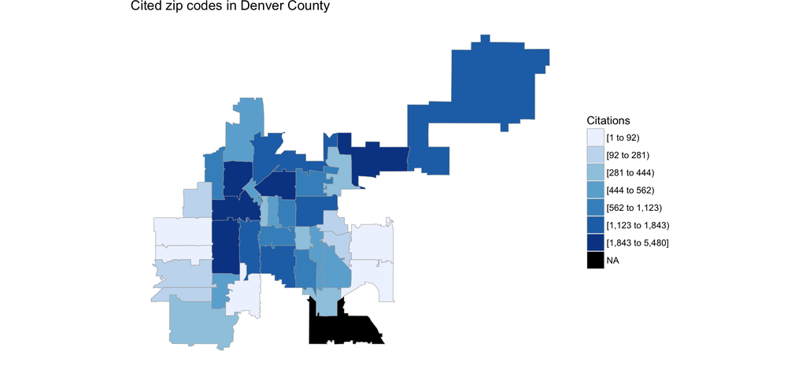

The full table of values is available in the appendix.

#### 3.0.1.2 Citations by type

In addition to investigating areas by pure citation number alone, it also seems prudent to delve into which ordinances are most problematic in the county generally and where they are most problematic specifically.

While original values can be found in the appendix, data cleaning was employed for the interpretation of this variable. For the sake of simplicity all rescinded (“RSCND”) violations or those that came into compliance (“COMP”) were removed from the dataset to avoid overcounting, leaving roughly 26,000 observations. Also logically if we are looking to prescribe interventions to curb infractions in the first place these types of citations wouldn’t be very helpful. Similarly, all “1st”, “2nd”, and “3rd” tags were removed, though those entries themselves were kept.

After sorting the data the top 5 offenses are:

|  | Offense number | Frequency |
| --- | --- | --- |
| 8 | 8-16 | 10358 |
| 20 | 8-61 | 5125 |
| 12 | 8-32 | 4251 |
| 22 | 8-70/71 | 2517 |
| 17 | 8-51 | 2199 |

#### 3.1.0.1 8-16 - Leash law

| Zip code | Frequency |
| --- | --- |
| 80219 | 1383 |
| 80211 | 758 |
| 80204 | 676 |

#### 3.1.0.2 8-61 - License required

| Zip code | Frequency |
| --- | --- |
| 80219 | 956 |
| 80239 | 479 |
| 80204 | 362 |

#### 3.1.0.3 8-32 - Rabies vaccination required

| Zip code | Frequency |
| --- | --- |
| 80219 | 979 |
| 80239 | 419 |
| 80204 | 301 |

# 4 Flaws, outstanding questions, and suggestions for future investigation

- Zip of owner vs. zip where offense was committed
- How to interpret rescinded and compliant citations
- Explanation for the large number of non-Denver zip codes
- Using census data to link zip codes with Denver neighborhoods and thus demographic information
- Getting more demographic information on owner along with citation information
- What are the importance of 1st, 2nd, and 3rd violations? What about ordinance violations that are almost never encountered/cited?

# 5 Appendix

### 5.0.1 All zip codes and number of offenses

| Zip code | Number of citations |
| --- | --- |
| 80219 | 5480 |
| 80239 | 2583 |
| 80204 | 2093 |
| 80205 | 1852 |
| 80211 | 1843 |
| 80216 | 1581 |
| 80223 | 1528 |
| 80220 | 1360 |
| 80210 | 1336 |
| 80249 | 1123 |
| 80207 | 1021 |
| 80206 | 770 |
| 80209 | 671 |
| 80212 | 639 |
| 80222 | 562 |
| 80224 | 526 |
| 80218 | 515 |
| 80221 | 515 |
| 80236 | 461 |
| 80202 | 444 |
| 80231 | 444 |
| 80203 | 388 |
| 80237 | 353 |
| 80238 | 329 |
| 80123 | 281 |
| 80246 | 281 |
| 80227 | 263 |
| 80230 | 262 |
| 80247 | 164 |
| 80214 | 102 |
| 80235 | 92 |
| 80226 | 89 |
| 80110 | 75 |
| 80014 | 65 |
| 80232 | 28 |
| 80012 | 20 |
| 80294 | 1 |

### 5.0.2 Original offense values

```
##  [1] 8-32 (1ST)    8-61 (1ST)    8-70/71 (1ST) 8-16          8-48
##  [6] 8-51          8-32 COMP     8-16 (1ST)    8-70/71 COMP  8-32 (2ND)
## [11] 8-70/71 RSCND 8-61 COMP     8-32 RSCND    8-36 (1ST)    8-63 (1ST)
## [16] 8-17 (1ST)    8-16 (3RD)    8-70/71 (2ND) 8-55          8-61 RSCND
## [21] 8-47 (1ST)    8-16 (2ND)    8-131         8-46          8-2
## [26] 8-132         8-17 (2ND)    8-61 (2ND)    8-121         8-131 (B)
## [31] 8-47          8-153.5(F)    8-52          8-82 (1ST)    8-91 (1ST)
## [36] 8-17          8-32 (3RD)    8-61 (3RD)    8-70/71 (3RD) 8-61
## [41] 8-32          8-82 (2ND)    8-71          8-132 (1ST)   8-2 (1ST)
## [46] 8-36 (2ND)    8-3 (1ST)     8-91          8-140         8-134
## [51] 8-63 (2ND)    8-3           8-91 (2ND)    8-140 (1ST)   8-140 (2ND)
## [56] 8-131(B)(1ST) 8-91 RSCND    8-46 (1ST)
## 58 Levels: 8-121 8-131 8-131 (B) 8-131(B)(1ST) 8-132 8-132 (1ST) ... 8-91 RSCND
```

|  | Offense.number | Frequency |
| --- | --- | --- |
| 13 | 8-16 (1ST) | 8039 |
| 40 | 8-61 (1ST) | 4425 |
| 24 | 8-32 (1ST) | 3696 |
| 47 | 8-70/71 (1ST) | 2480 |
| 36 | 8-51 | 2199 |
| 12 | 8-16 | 2141 |
| 44 | 8-61 RSCND | 1115 |
| 27 | 8-32 COMP | 963 |
| 43 | 8-61 COMP | 766 |
| 39 | 8-61 | 681 |

|  | Offense.number | Frequency |
| --- | --- | --- |
| 30 | 8-36 (2ND) | 2 |
| 32 | 8-46 (1ST) | 2 |
| 49 | 8-70/71 (3RD) | 2 |
| 10 | 8-140 (2ND) | 1 |
| 11 | 8-153.5(F) | 1 |
| 42 | 8-61 (3RD) | 1 |
| 46 | 8-63 (2ND) | 1 |
| 54 | 8-82 (2ND) | 1 |
| 57 | 8-91 (2ND) | 1 |
| 58 | 8-91 RSCND | 1 |

### 5.0.3 Denver County Zip Codes

#### 5.0.3.1 Final master list obtained by crosschecking

44 entries:

**80012 80014 80123 80202 80203 80204 80205 80206 80207 80209 80210 80211 80212 80214 80216 80218 80219 80220 80221 80222 80223 80224 80226 80227 80230 80231 80232 80235 80236 80237 80238 80239 80246 80247 80249 80264 80290 80293 80294 80110 80265 80266 80292 80295**

#### 5.0.3.2 Source: USPS

Original 73 entries in ‘denver, co’ region:

**80012 80014 80022 80033 80123 80127 80201 80202 80203 80204 80205 80206 80207 80208 80209 80210 80211 80212 80214 80215 80216 80217 80218 80219 80220 80221 80222 80223 80224 80225 80226 80227 80228 80229 80230 80231 80232 80233 80234 80235 80236 80237 80238 80239 80241 80243 80244 80246 80247 80248 80249 80250 80251 80252 80256 80257 80259 80260 80261 80262 80263 80264 80265 80266 80271 80273 80274 80281 80290 80291 8029380294 80299**

Subsequent 53 entries narrowed after eliminating unique zip codes used for a specific company or organization:

**80012 80014 80022 80033 80123 80127 80202 80203 80204 80205 80206 80207 80209 80210 80211 80212 80214 80215 80216 80218 80219 80220 80221 80222 80223 80224 80225 80226 80227 80228 80229 80230 80231 80232 80233 80234 80235 80236 80237 80238 80239 80241 80246 80247 80249 80260 80264 80265 80266 80290 80293 80294 80299**

#### 5.0.3.3 Source: R package ‘noncensus’

Original 75 entries in ‘denver’ region:

**80208 80217 80238 80243 80244 80248 80250 80251 80252 80254 80255 80257 80263 80265 80270 80271 80275 80279 80299 80201 80202 80203 80204 80205 80206 80207 80209 80210 80211 80212 80214 80215 80216 80218 80219 80220 80221 80222 80223 80224 80225 80226 80227 80228 80229 80230 80231 80232 80233 80234 80235 80236 80237 80239 80241 80246 80247 80249 80256 80292 80259 80260 80261 80262 80264 80266 80273 80274 80280 80281 80291 80290 80293 80294 80295**

Subsequent 37 entries narrowed using 8031 FIPS ([Federal Information Processing Standard](https://en.wikipedia.org/wiki/FIPS_county_code)) identifier:

**80202 80203 80204 80205 80206 80207 80209 80210 80211 80212 80216 80218 80219 80220 80223 80224 80230 80236 80237 80239 80249 80256 80292 80259 80261 80262 80264 80266 80273 80274 80280 80281 80291 80290 80293 80294 80295**

#### 5.0.3.4 Source: R package ‘choroplethrZip’

41 entries:

**80294 80235 80236 80218 80203 80222 80220 80202 80223 80012 80207 80110 80204 80206 80290 80247 80293 80226 80205 80224 80232 80237 80211 80249 80219 80123 80216 80014 80212 80264 80227 80111 80214 80246 80221 80230 80238 80231 80209 80239 80210**

### 5.0.4 Denver Animal Ordinances

| Ordinance.No. | Name | Description |
| --- | --- | --- |
| Sec. 8-134. | Abandonment | Abandoning an animal is a crime. After leaving notices, Denver Animal Shelter has the authority to impound any animal that appears to be abandoned. |
| Sec. 8-46. | Barking dog nuisance | It shall be unlawful for any owner, possessor or keeper of any dog to permit such dog to disturb any person or neighborhood by loud and persistent or habitual barking, howling or yelping. No summons a… |
| Sec. 8-131. | Cruelty to animals prohibited | It shall be unlawful for any person to needlessly beat, inflict violence upon or kill, overwork, torture or mutilate, or to otherwise treat in a cruel, dangerous or inhumane manner, any animal, or to … |
| Sec. 8-47. | Disposition of excrement | It shall be unlawful for any person who possesses, harbors or is in charge of any dog, cat or other animal not to immediately remove excrement deposited by the animal upon a common thoroughfare, stree… |
| Sec. 8-48. | Damaging property | It shall be unlawful for any owner, possessor or person who keeps any dog, cat or other animal to permit such animal, whether or not running at large, to destroy, damage or injure any shrubbery, plant… |
| Sec. 8-52. | Dangerous dogs | No person who owns, possesses, keeps or exercises any control over a dangerous dog shall permit such dog to be on the premises of such person without being confined. No person who owns, possesses, kee… |
| Sec. 8-51. | Dog attack or bite | No person who owns, possesses, keeps or exercises control over any dog shall do the following: (1) Permit the dog to attack or bite any person or domestic animal not on the premises of such owner, pos… |
| Sec. 8-31. | Failure to vaccinate | It shall be unlawful for the owner of any domestic dog or cat over the age of six (6) months to possess, keep or maintain within the city any dog or cat that is not currently vaccinated for rabies in … |
| Sec. 8-32. | Rabies vaccination required | It shall be unlawful for any person who owns or harbors any dog or cat in the city to fail to have such dog or cat vaccinated for rabies by a licensed Colorado veterinarian, unless such person present… |
| 8-91 | Food producing animals | A Food Producing Animal (Restricted Livestock or Fowl) Permit is required for the keeping of up to eight (8) ducks and or chickens combined, and up to two (2) dwarf goats (dwarf goats shall mean Niger… |
| Zoning Code 11.8.5 | Keeping of Household Animals | The Denver Zoning Code regulates how many household pets can be part of a home residence. Violations occur when the number of household pets exceeds 3 dogs, 5 cats, 2 rabbits, or 25 pigeons, or 5 tota… |
| Sec. 8-2. | Keeping wild or dangerous animals prohibited | Section 8-2 of the Denver Municipal Code identifies animal species deemed to be wild or dangerous. The owning, possessing, keeping, maintaining, harboring, transporting, or selling of any animal deeme… |
| Sec. 8-16. | Leash law | Dogs are required to be on a leash and under control of their owner, at all times. |
| Sec. 8-61. | License required | It shall be unlawful for the owner, possessor or keeper of any domestic dog (Canis Familiaris) over the age of six (6) months or domestic cat (Felis catus) over the age of six (6) months to keep, main… |
| 8-91(a) | Livestock or fowl permit required | A Livestock or Fowl Permit allows an individual to keep livestock or fowl such as, but not limited to, horses, mules, donkeys, burros, cattle, sheep, goats, swine, chickens, geese, ducks, or turkeys o… |
| Sec. 8-132. | Neglect of animals prohibited | The Denver Animal Shelter has authority to impound any animal that shows signs of neglect (ex. malnourishment). |
| Sec. 8-55. | Pit bulls prohibited | It shall be unlawful for any person to own, possess, keep, exercise control over, maintain, harbor, transport, or sell within the city any pit bull. |
| Sec. 8-136. | Poisoning | It shall be unlawful for any person to poison any domestic animal in any manner whatsoever with the intent or for the purpose of poisoning such animal. |
| Sec. 8-121. | Quarantine | Whenever the owner or possessor of an animal has been notified by any person, whether or not an agent of the manager, or has other cause to believe that the owner’s or possessor’s animal has bitten or… |
| Sec. 8-32. | Rabies vaccination required | It shall be unlawful for any person who owns or harbors any dog or cat in the city to fail to have such dog or cat vaccinated for rabies by a licensed Colorado veterinarian, unless such person present… |
| Sec. 8-70. | Spaying and neutering | Spay/neuter is required for dogs and cats living in the City and County of Denver. |
| Sec. 8-140. | Trapping of animals | It shall be unlawful to use or set a leg-hold, snare, instant kill-body-gripping trap, or trap which can cause pain, injury or suffering to any animal, except for any mouse or rat snap-type or glue bo… |

([Source](https://www.denvergov.org/content/denvergov/en/denver-animal-shelter/animal-protection/denver-animal-ordinances.html); [More information](https://library.municode.com/co/denver/codes/code_of_ordinances?nodeId=REMUCOCODECO))

### 5.0.5 Other sources

- https://www.denvergov.org/media/gis/WebDocs/Citywide/Neighborhoods.pdf
- http://www.nws.noaa.gov/mirs/public/prods/maps/cnty_fips_colorado.htm
- https://www.nrcs.usda.gov/wps/portal/nrcs/detail/?cid=nrcs143_013697
- https://www2.census.gov/geo/docs/reference/codes/files/st08_co_cou.txt
- https://www.census.gov/geo/reference/codes/cou.html
- https://cengel.github.io/rspatial/4_Mapping.nb.html
- https://andrewbtran.github.io/NICAR/2017/maps/mapping-census-data.html
- http://unconj.ca/blog/choropleth-maps-with-r-and-ggplot2.html
- https://cran.r-project.org/doc/contrib/intro-spatial-rl.pdf
- http://journocode.com/2016/01/28/your-first-choropleth-map/
- Hampden, Baker, Washington Park, Cherry Creek, Country Club, Clayton, Skyland, City Park West, Capitol Hill, North Capitol Hill, Civic Center, CBD, Union Station, Five Points, Stapleton, Highland, Globeville, University Park, Cory – Merrill, Washington Park West, Speer, Congress Park, Cole, Sunnyside, Ruby Hill, University, Goldsmith, Virginia Village, DIA, University Hills, West Colfax, West Highland, Southmoor Park, Indian Creek, East Colfax, Rosedale, City Park, Lowry Field, Harvey Park South, Gateway / Green Valley Ranch, Barnum West, Montclair, Platt Park, Mar Lee, Westwood, Washington Virginia Vale, Villa Park, Hale, North Park Hill, South Park Hill, Kennedy, College View / South Platte, Hampden South, Northeast Park Hill, Elyria Swansea, Overland, Cheesman Park, Hilltop, Lincoln Park, Auraria, Belcaro, Windsor, Sloan Lake, Berkeley, Regis, Sun Valley, Wellshire, Jefferson Park, Valverde, Athmar Park, Chaffee Park, Harvey Park, Barnum, Whittier, Montbello, Marston, Fort Logan, Bear Valley